# Challenge Data Meta Analysis

Last modified on 2022-11-01

## Background

DREAM challenges lead the field of crowdsourced benchmarking in biomedical sciences. Between 2012 - 2021, DREAM has organized and completed almost 45 challenges. While most of the challenge outcomes have been documented, evaluated, and published in well-known peer reviewed journals, it is time to review the challenges themselves to understand more about what makes challenges successful and what could be improved upon.

## Question

- Do **DREAM** challenges form clusters according to features?

## Input Data

[Collated Challenge Features](https://docs.google.com/spreadsheets/d/1oiUUcNZdZ-EccKtZpG_o7DLiKM8F5n69YScqjkpC0X8/edit#gid=0)

```
## Rows: 45
## Columns: 38
## $ challengeName               <chr> "Network Topology and Parameter Inference"…
## $ challengeSite               <chr> "https://www.synapse.org/#!Synapse:syn2821…
## $ challengeYear               <chr> "2012", "2012", "2012", "2012", "2013", "2…
## $ challengeAge                <chr> "10", "10", "10", "10", "9", "9", "9", "8"…
## $ challengeSponsors           <chr> "European Union", "Columbia University", "…
## $ sponsorTiers                <chr> "Government", "Academic", "", "Government"…
## $ dataContributors            <chr> "", "BC Cancer Research Centre, Cancer Res…
## $ contributorTiers            <chr> "", "Academic, Other", "Industrial, Academ…
## $ numberOfSubChallenges       <chr> "2", "1", "1", "2", "2", "3", "4", "2", "7…
## $ numberOfSubmissions         <chr> "", "", "", "", "", "", "", "", "", "", ""…
## $ numberTotalSubmissions      <chr> "", "", "", "", "184", "23", "178", "55", …
## $ numberOfTotalRegistrants    <chr> "", "", "", "", "", "", "", "378", "602", …
## $ numberOfTeams               <chr> "", "", "", "", "", "", "", "", "", "", ""…
```

[output cut: 25 more lines]

### Current Selected/Used Features

```
## Rows: 45
## Columns: 23
## $ challengeAge             <dbl> 10, 10, 10, 10, 9, 9, 9, 8, 8, 8, 8, 8, 7, 7,…
## $ numberTotalSubmissions   <dbl> NA, NA, NA, NA, 184, 23, 178, 55, 2823, 63, 8…
## $ numberOfTotalRegistrants <dbl> NA, NA, NA, NA, NA, NA, NA, 378, 602, 286, 35…
## $ numberOfDataTypes        <dbl> 4, 5, 1, 10, 5, 8, 2, 4, 2, 2, 4, 3, 1, 6, 3,…
## $ numberOfSubChallenges    <dbl> 2, 1, 1, 2, 2, 3, 4, 2, 7, 3, 3, 3, 2, 3, 4, …
## $ numberOfUserTeams        <dbl> NA, NA, NA, NA, NA, NA, NA, NA, NA, NA, NA, N…
## $ numberOfUsers            <dbl> NA, NA, NA, NA, NA, NA, NA, NA, NA, NA, NA, N…
## $ numberOfFollowers        <dbl> 0, 0, 1, 1, 0, 0, 0, 0, 0, 0, 1, 3, 0, 0, 0, …
## $ numberOfTopics           <dbl> 0, 0, 0, 0, 0, 0, 0, 0, 8, 0, 0, 1, 0, 0, 0, …
## $ numberOfAuthors          <dbl> 0, 0, 0, 0, 0, 0, 0, 0, 8, 0, 0, 1, 0, 0, 0, …
## $ numberOfThreads          <dbl> 0, 0, 0, 0, 0, 0, 0, 0, 22, 0, 0, 2, 0, 0, 0,…
## $ moderatorsAttribution    <dbl> 0.0000000, 0.0000000, 0.0000000, 0.0000000, 0…
## $ maxActiveUserPerThread   <dbl> 0, 0, 0, 0, 0, 0, 0, 0, 5, 0, 0, 2, 0, 0, 0, …
## $ maxRepliesPerThread      <dbl> 0, 0, 0, 0, 0, 0, 0, 0, 7, 0, 0, 3, 0, 0, 0, …
## $ maxViewsPerThread        <dbl> 0, 0, 0, 0, 0, 0, 0, 0, 57, 0, 0, 12, 0, 0, 0…
## $ avgResponsesPerThread    <dbl> 0.000000, 0.000000, 0.000000, 0.000000, 0.000…
## $ AvgResponsesPerCommenter <dbl> 0.000000, 0.000000, 0.000000, 0.000000, 0.000…
## $ dataTypeTiers            <fct> "genomic, proteomic, other", "demographic, cl…
## $ sponsorTiers             <fct> "Government", "Academic", "", "Government", "…
## $ contributorTiers         <fct> "", "Academic, Other", "Industrial, Academic,…
## $ modelContainerization    <fct> FALSE, FALSE, FALSE, FALSE, FALSE, FALSE, FAL…
## $ monetaryIncentive        <fct> FALSE, FALSE, TRUE, FALSE, FALSE, FALSE, TRUE…
## $ speakingIncentive        <fct> FALSE, TRUE, FALSE, FALSE, TRUE, TRUE, FALSE,…
```

- **Numerical Data**: `challengeAge, numberTotalSubmissions, numberOfTotalRegistrants, numberOfDataTypes, numberOfSubChallenges, numberOfUserTeams, numberOfUsers, numberOfFollowers, numberOfTopics, numberOfAuthors, numberOfThreads, moderatorsAttribution, maxActiveUserPerThread, maxRepliesPerThread, maxViewsPerThread, avgResponsesPerThread, AvgResponsesPerCommenter`
- **Categorical Data**: `dataTypeTiers, sponsorTiers, contributorTiers`
- **Logical Data**: `modelContainerization, monetaryIncentive, speakingIncentive`

## Data Transformation

The continuous data is strong positively skewed. We will need to apply the log transformation on continuous data before performing clustering or PCA.

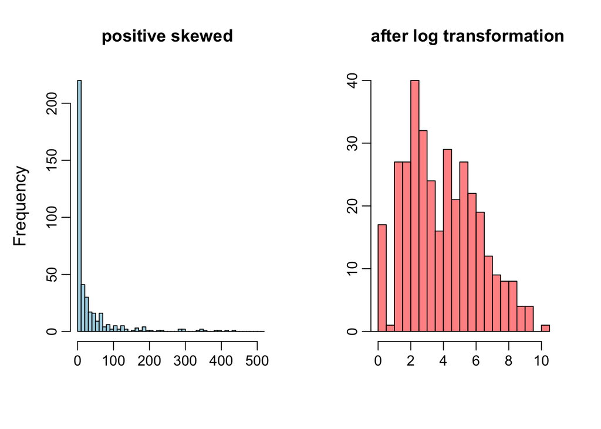

## Exploratory Heatmap

I have initially one-hot encode categorical features and did clustering with the euclidean distance. However, various types of categorical data introduces large sparsity in the heatmap and one-hot encoding is not easy to interpret with many missing data.

Alternatively, we chose “Gower Distance”. Gower is a distance method popularly used for mixed type data: - It can handle missing data - It works with mixed data types. It calculates similarity coefficients using specific metrics for each data type (continuous, ordinal, categorical) - The distance matrix it creates is easily interpretable on a heatmap

### All challenges

#### Gower distance heatmap

Create heatmap using gower distance to explore pattern. The number of participants and registrants were excluded. The dissimilarity matrix/distance matrix is calculated using `cluster::daisy` function.

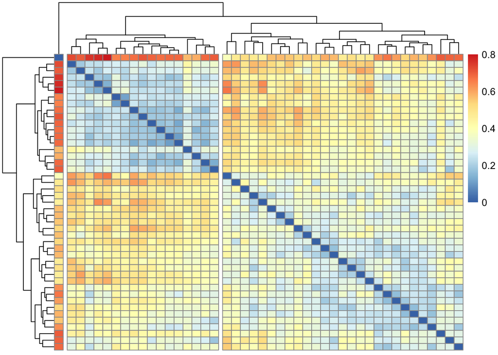

#### Partition Around Medoids (PAM)

We chose Partition Around Medoids (PAM) to further determine the number of clusters. According to the Silhouette plot, when k = 2, challenges will have the highest Silhouette width.

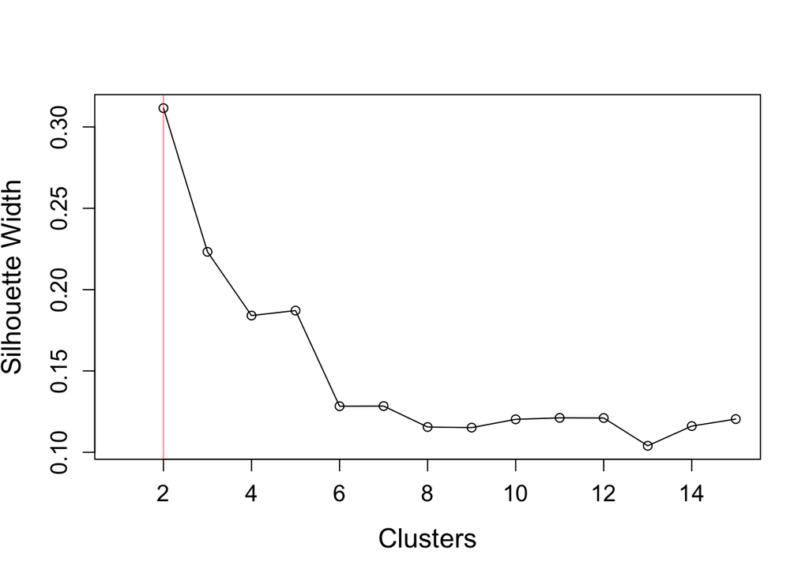

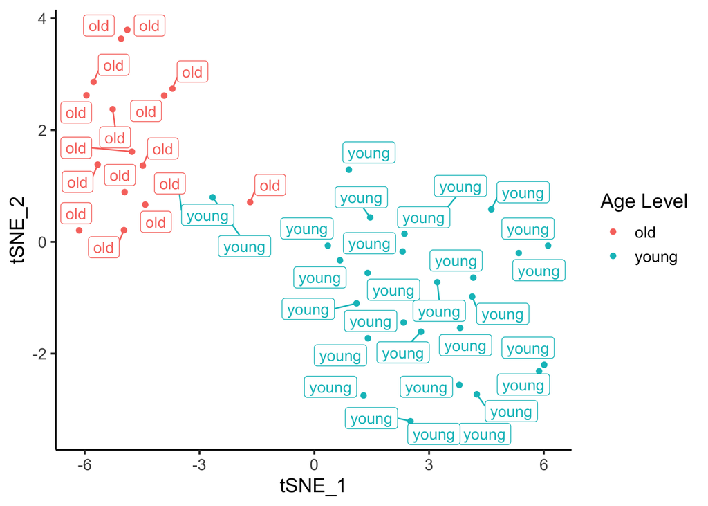

Since user engagement data was not well applied until 2016, it makes sense that there are two clear clusters of challenges by the ages.

#### Feature summary by clusters

#### Boxplot by clusters

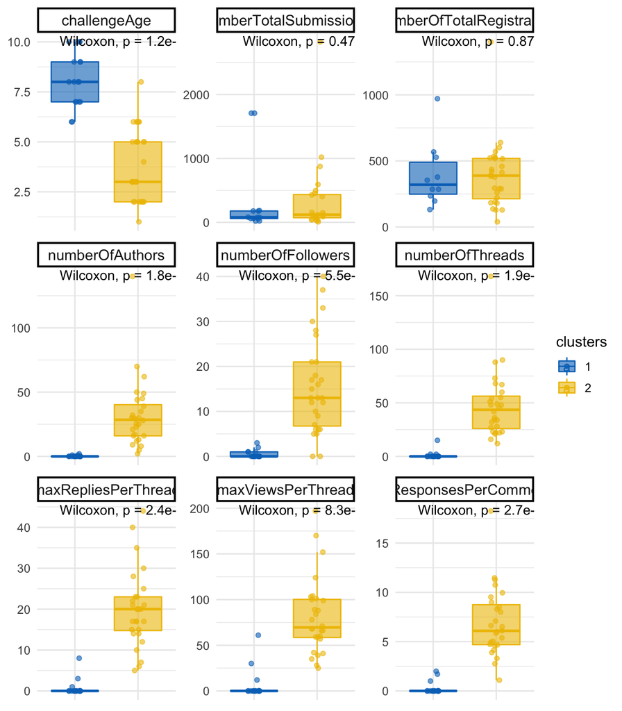

```
##         dataTypeTiers          sponsorTiers      contributorTiers
##            0.49474496            0.42975553            0.02753499
## modelContainerization     monetaryIncentive     speakingIncentive
##            0.02753499            1.00000000            0.27029760
```

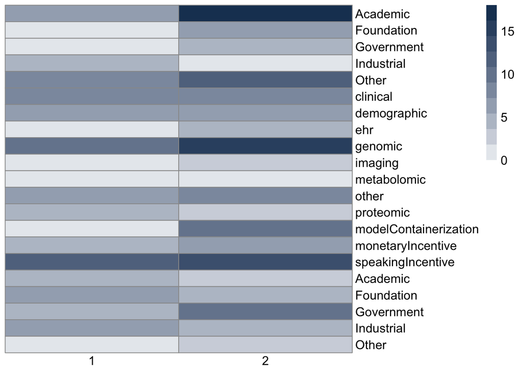

### Young challenges Only

#### Analysis on the challenges from cluster 2 (young challenges)

#### Sub-clustering

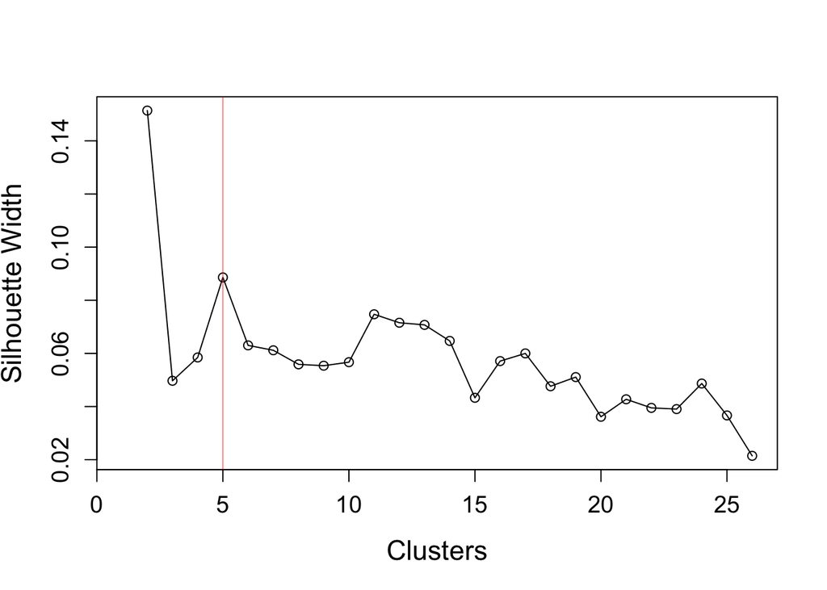

#### TSNE

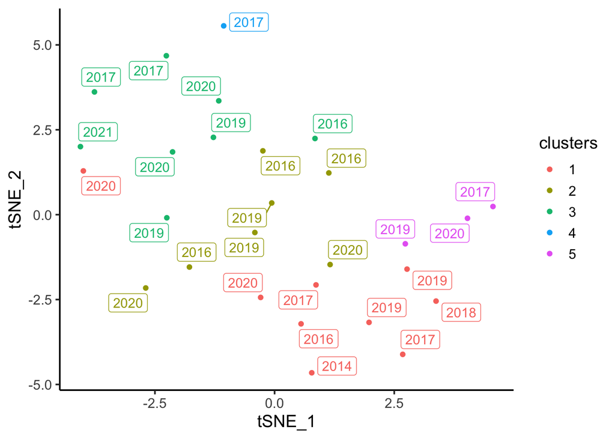

#### Feature boxplot by clusters

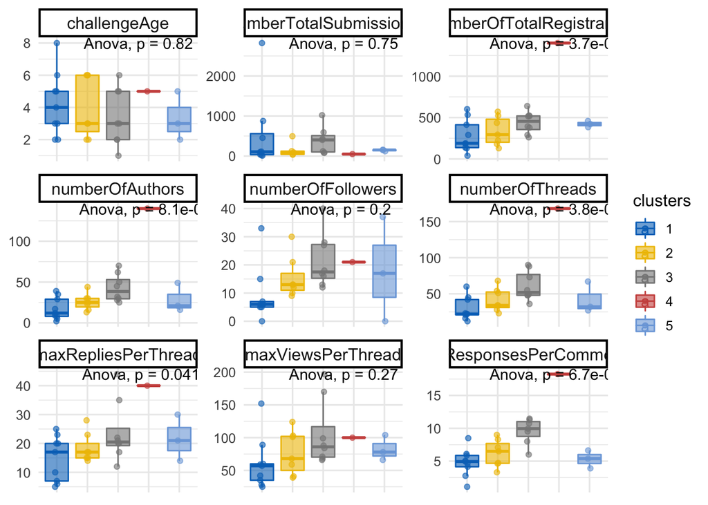

```
##         dataTypeTiers          sponsorTiers      contributorTiers
##           0.593103448           0.038230885           0.863068466
## modelContainerization     monetaryIncentive     speakingIncentive
##           0.002998501           0.038230885           0.011994003
```

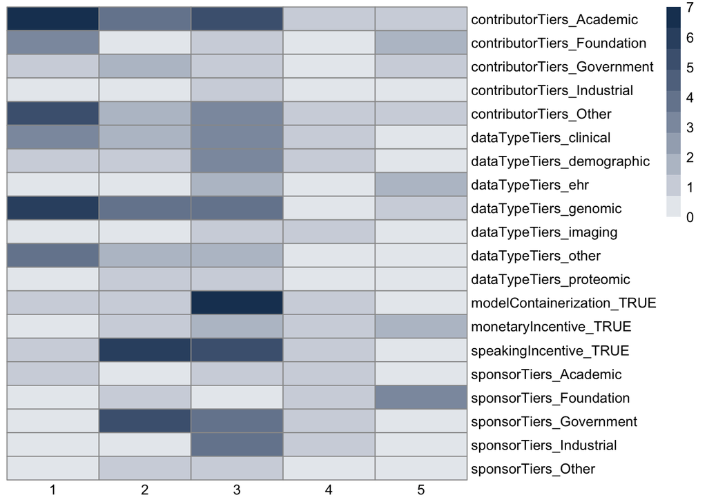